# Technical Team

## Ugoji Adanma Eze, Esq., PhD, FEGSB

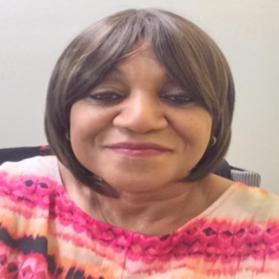

### Founder

Ugoji Adanma Eze, Esq., PhD, FEGSB, is the founder of our technical team. With a robust background in law and extensive experience in international affairs, she has made significant contributions across various fields. Ugoji has authored several publications on diverse topics such as human rights, nuclear terrorism, female suicide bombers, cyber security, and the US commitment to refugees. She has served as the Focal Point of the Commission on the Status of Women NGO Women Peace and Security and is actively involved in organizations such as the International Association of Jewish Lawyers and Jurists, the Nigeria Bar Association, and the New York City Bar. Ugoji has spoken at numerous prestigious events, including those at the United Nations and Columbia University. Her expertise and dedication make her a valuable asset to our technical team.

## Dr. Si Chen

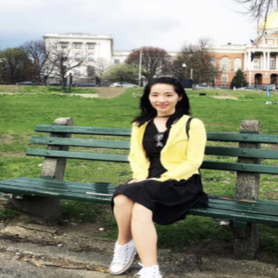

### Marketing And Social Media Analyst, Senior Advisor to Dr. Ugoji A. Eze

Dr. Si Chen is a respected member of our technical team with a rich background in international relations. Her expertise lies in United Nations peacekeeping operations, digital government, and sustainable development. Before joining Mishkan Holdings LLC, she served at the Digital Government Branch, UN Department of Economic and Social Affairs. Dr. Chen holds a Ph.D. in political science from the State University of New York at Buffalo and an LL.B in international relations from Xi’an International Studies University.

## Shaun Porwal

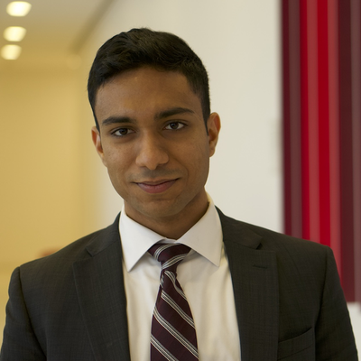

### Data And Information Analyst

Shaun Porwal, based in New York, is a Biomedical Data Scientist with a B.E. in Biomedical Engineering from Rutgers University and an M.S. in Biomedical Data Science from Mount Sinai. He currently serves as a Data Analyst and Research Biostatistician at Memorial Sloan Kettering Cancer Center. He brought clinical model evaluation to the Python community by writing the ‘dcurves’ package based on Decision Curve Analysis, and routinely contributes to statistical sections in urological cancer publications. Shaun has extensive experience from roles at Sema4 and Rutgers University, developing algorithms for time-series gene expression and performing structural variant detection on large data sets. He’s proficient in several programming languages, including Python & R, and is multilingual, speaking English, Hindi, Mandarin, and Japanese. Outside of work, Shaun enjoys exploring languages, traveling, and running.

## H.E. Laila Rahhal El Atfani

[figure not shown]

### Gender Empowerment And Sustainable Development

H.E. Laila Rahhal El Atfani is a renowned professional and entrepreneur known for her impactful work in various fields. She is the President and Founder of Business Gate, the I AM AFRICA platform, and Woman Business Circle. Laila has a strong media presence and is recognized as a Goodwill Ambassador and an International Ambassador of Peace and Tolerance. She holds prestigious positions such as the Head of Protocol and Diplomacy at AACID and WPC, and she’s actively involved in organizations like REFAI NGO and MACAN Fuel & Petroleum Trading. Dedicated to empowering women and youth, Laila has served as the President of the Economic Platform, United Youth Circuit, and Women Empowerment and International Relations with Anwour Association in Morocco. She has received numerous commendations for her inspiring leadership and commitment to societal betterment.

## Pradeep Sapkota

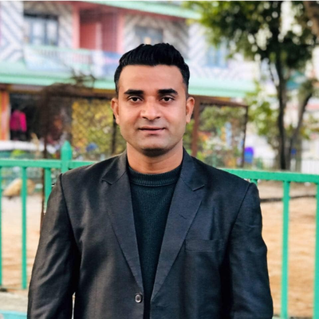

### SDGs, Environmental Sustainability, and Climate Change

Datu Pradeep Sapkota is an internationally recognized Youth Activist and Peace Ambassador, adopted as a noble son by The Royal House of Baloi, Philippines. As the Founder/Director of the SUNWay Research and Innovation Center, and the Country Director for ONE WORLD Citizens in the Netherlands, Sapkota leads significant global initiatives. His background includes roles as a computer technician, software programmer, and an Information and Communication Technology trainer. His efforts have garnered numerous awards, including the “International Peace & Humanity Grand Award 2019.” His work focuses on gender equality, environmental sustainability, food security, and community development.